# Introduction to R Markdown

31 October, 2017

## What is R?

- R is a language and environment for statistical computing and graphics. It is a GNU project which is similar to the S language and environment which was developed at Bell Laboratories (much code written for S runs unaltered under R).

## why using R and RMarkdown?

1. It is free and open source (GNU General Public License in source code form)
2. Time and processing efficient
3. Many libraries (linear and nonlinear modelling, classical statistical tests, time-series analysis, classification, clustering, etc)
4. Continuosly improved and developed by the R community
5. Well documented (your answer will be usually found in stackoverflow)
6. It makes statistical analysis reproducible to others
7. It is a multiplatform system (FreeBSD, Linux, Windows and MacOS)
8. well-designed publication-quality plots can be produced
9. It is nice

## R IDE

- R Studio is a nice Interface development enviorment to use R

## Libraries

-There are many R libraries which can be installed and loaded.

## Usefurl links

- [Rmarkdown](http://rmarkdown.rstudio.com/lesson-1.html)
- [Chunks](http://rmarkdown.rstudio.com/authoring_rcodechunks.html)

## Data Frames

- Data Frames contain and allow to manipulate data in many ways. Imported data from Excel, SPPS, cvc, txt and other formats can be loaded into R data frames

```
##   subject Age_years Sex right_dB_HL_250_Hz right_dB_HL_500_Hz
## 1     1WR  48.11781   M                 20                 20
## 2     2PP  22.35616   F                 -5                 -5
##   right_dB_HL_1000_Hz right_dB_HL_2000_Hz right_dB_HL_4000_Hz
## 1                  20                  15                  10
## 2                 -10                  -5                  10
##   right_dB_HL_8000_Hz left_dB_HL_250_Hz left_dB_HL_500_Hz
## 1                  35                25                50
## 2                  10                -5                -5
##   left_dB_HL_1000_Hz left_dB_HL_2000_Hz left_dB_HL_4000_Hz
## 1                 25                 15                 20
## 2                 -5                 -5                 -5
##   left_dB_HL_8000_Hz right_ave left_ave left_right_ave better_ear_ave
## 1                 25        17       27             22             17
## 2                  5        -3       -5             -4             -5
##   left_right_ave_dB_HL_4000_Hz better_ear_dB_HL_4000_Hz
## 1                         15.0                       10
## 2                          2.5                       -5
##   left_right_ave_dB_HL_500_Hz better_ear_dB_HL_500_Hz
## 1                          35                      20
## 2                          -5                      -5
```

## Descriptive statistics

```
##     subject     Age_years     Sex    right_dB_HL_250_Hz right_dB_HL_500_Hz
##  10AA   : 1   Min.   :20.09   F:10   Min.   :-5.000     Min.   :-5.0
##  11RR   : 1   1st Qu.:24.45   M: 9   1st Qu.: 0.000     1st Qu.: 0.0
##  12SR   : 1   Median :35.19          Median : 0.000     Median : 5.0
##  13BL   : 1   Mean   :34.43          Mean   : 4.211     Mean   : 5.0
##  14PT   : 1   3rd Qu.:39.67          3rd Qu.: 5.000     3rd Qu.: 7.5
##  15SE   : 1   Max.   :54.00          Max.   :30.000     Max.   :25.0
##  (Other):13
##  right_dB_HL_1000_Hz right_dB_HL_2000_Hz right_dB_HL_4000_Hz
##  Min.   :-10.000     Min.   :-5.000      Min.   :-5.000
##  1st Qu.:  0.000     1st Qu.: 0.000      1st Qu.: 0.000
##  Median :  5.000     Median : 0.000      Median : 5.000
##  Mean   :  6.053     Mean   : 3.158      Mean   : 6.316
##  3rd Qu.: 10.000     3rd Qu.: 5.000      3rd Qu.:10.000
##  Max.   : 20.000     Max.   :15.000      Max.   :30.000
##
##  right_dB_HL_8000_Hz left_dB_HL_250_Hz left_dB_HL_500_Hz
##  Min.   :-5.00       Min.   :-5.000    Min.   :-10.000
##  1st Qu.: 2.50       1st Qu.:-5.000    1st Qu.:  0.000
##  Median :10.00       Median : 0.000    Median :  0.000
##  Mean   :10.53       Mean   : 2.105    Mean   :  3.421
##  3rd Qu.:15.00       3rd Qu.: 5.000    3rd Qu.:  5.000
##  Max.   :40.00       Max.   :25.000    Max.   : 50.000
##
##  left_dB_HL_1000_Hz left_dB_HL_2000_Hz left_dB_HL_4000_Hz
##  Min.   :-5.000     Min.   :-5.000     Min.   :-10.000
##  1st Qu.: 0.000     1st Qu.: 0.000     1st Qu.:  0.000
##  Median : 0.000     Median : 0.000     Median :  5.000
##  Mean   : 2.632     Mean   : 2.895     Mean   :  6.842
##  3rd Qu.: 5.000     3rd Qu.: 5.000     3rd Qu.: 12.500
##  Max.   :25.000     Max.   :15.000     Max.   : 30.000
##
##  left_dB_HL_8000_Hz   right_ave         left_ave      left_right_ave
##  Min.   :-10.0      Min.   :-3.000   Min.   :-5.000   Min.   :-4.000
##  1st Qu.:  2.5      1st Qu.: 1.500   1st Qu.: 0.500   1st Qu.: 1.500
##  Median : 10.0      Median : 3.000   Median : 2.000   Median : 3.000
##  Mean   : 10.0      Mean   : 4.947   Mean   : 3.579   Mean   : 4.263
##  3rd Qu.: 15.0      3rd Qu.: 9.000   3rd Qu.: 5.000   3rd Qu.: 5.750
##  Max.   : 40.0      Max.   :17.000   Max.   :27.000   Max.   :22.000
##
##  better_ear_ave   left_right_ave_dB_HL_4000_Hz better_ear_dB_HL_4000_Hz
##  Min.   :-5.000   Min.   :-2.500               Min.   :-10.000
##  1st Qu.: 0.500   1st Qu.: 0.000               1st Qu.: -5.000
##  Median : 2.000   Median : 5.000               Median :  5.000
##  Mean   : 2.895   Mean   : 6.579               Mean   :  3.684
##  3rd Qu.: 4.500   3rd Qu.:11.250               3rd Qu.: 10.000
##  Max.   :17.000   Max.   :30.000               Max.   : 30.000
##
##  left_right_ave_dB_HL_500_Hz better_ear_dB_HL_500_Hz
##  Min.   :-5.000              Min.   :-10.000
##  1st Qu.: 0.000              1st Qu.: -2.500
##  Median : 2.500              Median :  0.000
##  Mean   : 4.211              Mean   :  1.053
##  3rd Qu.: 5.000              3rd Qu.:  5.000
##  Max.   :35.000              Max.   : 20.000
##
```

## Data frame from wide to long format

```
##   subject Age_years Sex dBHL   EAR Frequency
## 1     1WR  48.11781   M   20 right       250
## 2     2PP  22.35616   F   -5 right       250
## 3     3LS  25.58356   M   -5 right       250
## 4     4BB  39.73973   F    5 right       250
## 5     5MD  47.80000   M    0 right       250
```

## Plotting with ggplot

## Plotting with ggplot

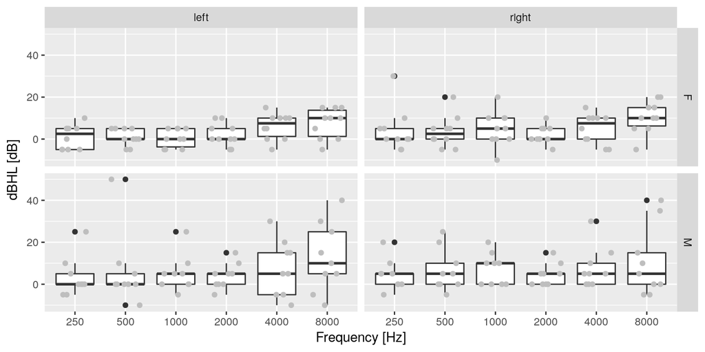

My cool caption

## Adding new Factors

```
##    subject Age_years Sex dBHL   EAR AGE_GROUP
## 1      1WR  48.11781   M   20 right  above_35
## 2      2PP  22.35616   F   -5 right  below_35
## 3      3LS  25.58356   M   -5 right  below_35
## 4      4BB  39.73973   F    5 right  above_35
## 5      5MD  47.80000   M    0 right  above_35
## 6      6DD  49.87397   F    0 right  above_35
## 7      8BV  39.60822   F    0 right  above_35
## 8      9VF  38.01918   M    5 right  above_35
## 9     10AA  20.09041   F   10 right  below_35
## 10    11RR  23.01096   F   30 right  below_35
```

## Plotting with ggplot

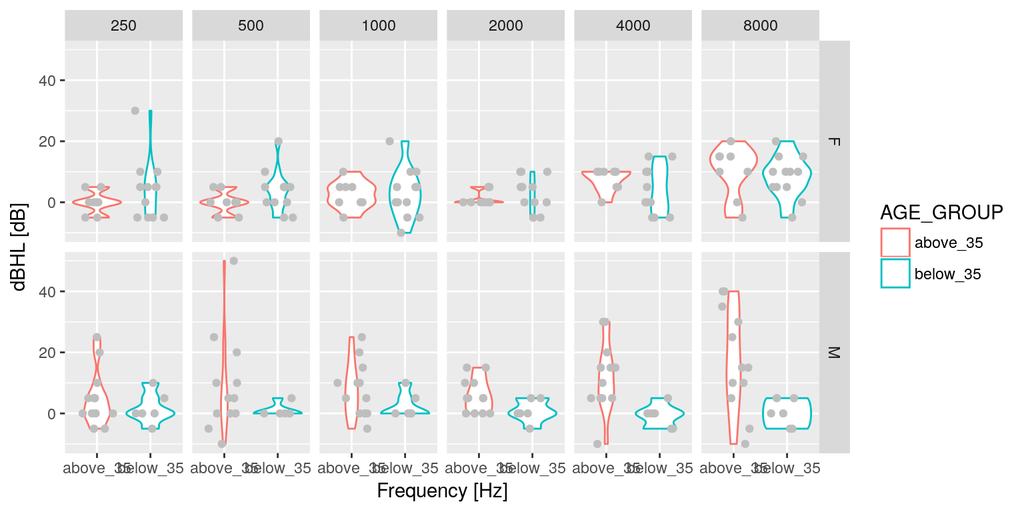